# Norwood Farm project

# 1 Open questions

- **How many ES are provided by species and habitats? Is the indirect contribution of species on ES (indirect effects) greater than the direct provision? Does it change according to species trophic group?**

- **How the direct (and indirect) provision of ecosystem (dis)service change according to habitat management? Is it related to the changes in the structure of the network?**

- **Are some species more robust to habitat management? Are those that provide more direct and indirect ES?**

# 2 Data (What we have)

- 12 habitat types (6 cultivable, 6 uncultivated).

- 23 fields in total.

- Records of antagonistic and mutualistic interactions. Abundances/area.

- 2 years

# 3 Previous analysis

Bayesian network approach to analyze if threats (habitat loss) towards specific species cause secondary extinctions of other species and affect ecosystem service provision.

## 3.1 Network

Unipartite, binary, all habitats aggregated.

## 3.2 Pros

- Computation time is reduced.

- Consider response of each consumer to the loss of its resources.

## 3.3 Cons

- Aggregated data (avoids spatial aspect).

- Habitat loss simulation instead of change of habitat management scenario (for example, from extensive to semi-extensive).

- Binary network (presence/absence of links).

# 4 Provision of Ecosystem (dis)services

We detected the direct provision of E(D)S by species and the potential indirect effects of species on E(D)S:

- **Direct E(D)S provision**: benefits (ES) or disadvantages (EDS) that result directly from the presence of a species.
- **Indirect effect on E(D)S provision**: impact of a species on ecosystem services or ecosystem disservices provided by another species.

## 4.1 Network

Multilayer network containing:

- Layers: Habitats.
- Nodes: Species. Associated attributes: trophic group and ES provided.
- Intralayer links: interaction between species. Binary: presence/absence.
- No interlayer links (for now…).

## 4.2 Method

We detected indirect effects of a target species on ecosystem services based on its neighbors. We calculated first and second order indirect interactions for each species.

### 4.2.1 First-order indirect interactions (1 hop):

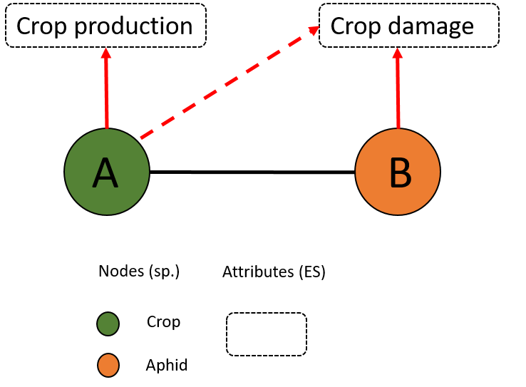

**Node A:**

Direct provision: Crop production

Indirect effect on: Crop damage

### 4.2.2 Second-order indirect interactions (2 hops):

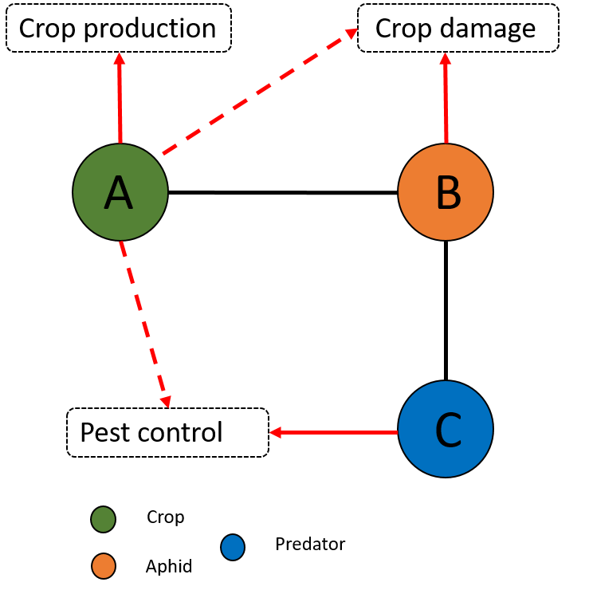

**Node A:**

Direct provision: Crop production

Indirect effect on: Crop damage

Indirect effect on: Pest control

## 4.3 Number and prop. of ES /hab

### 4.3.1 Number of direct and indirect ES

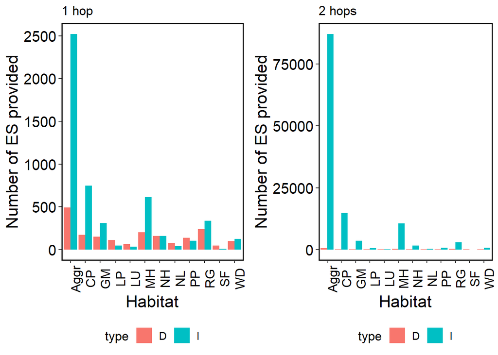

### 4.3.2 Prop of direct and indirect ES / hab

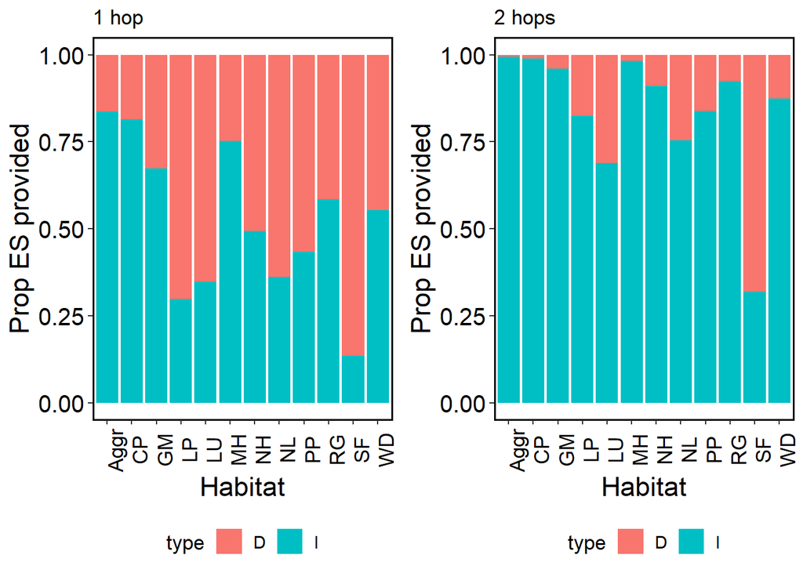

## 4.4 Prop. ES provided per taxon/habitat

### 4.4.1 Considering 1 hop

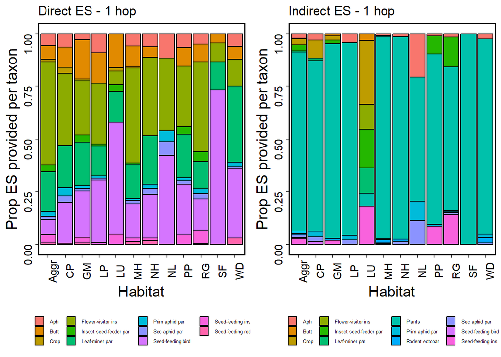

### 4.4.2 Considering 2 hops

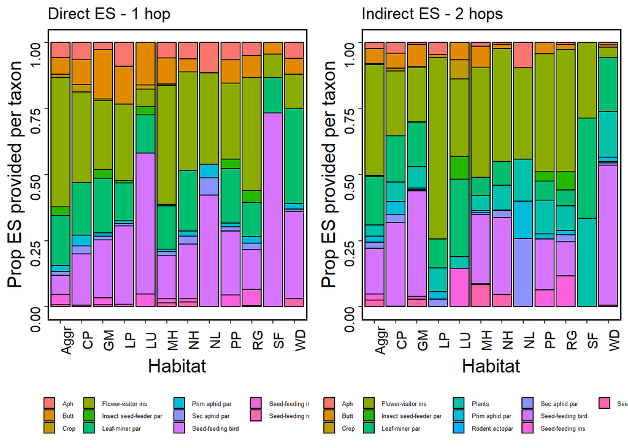

## 4.5 Cons

- Non-weighted ecosystem services (presence/absence of direct or indirect ES)

# 5 Output of direct and indirect effects on ES

For each interaction, we assigned the following outputs:

- **+** : provides ES, increases ES provision or decreases crop damage.
- **-** : provides E(D)S (crop damage), decreases ES provision or increases crop damage)

## 5.1 Prop. of output per habitat

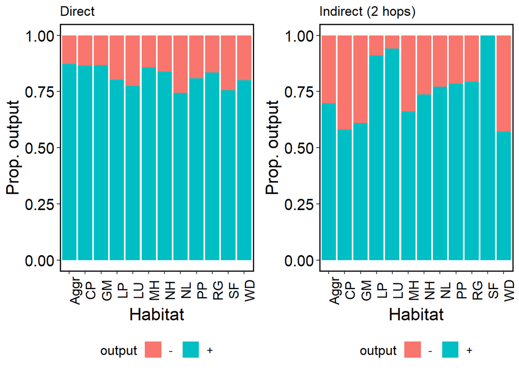

## 5.2 Prop. of output according to taxon / habitat

### 5.2.1 Direct ES

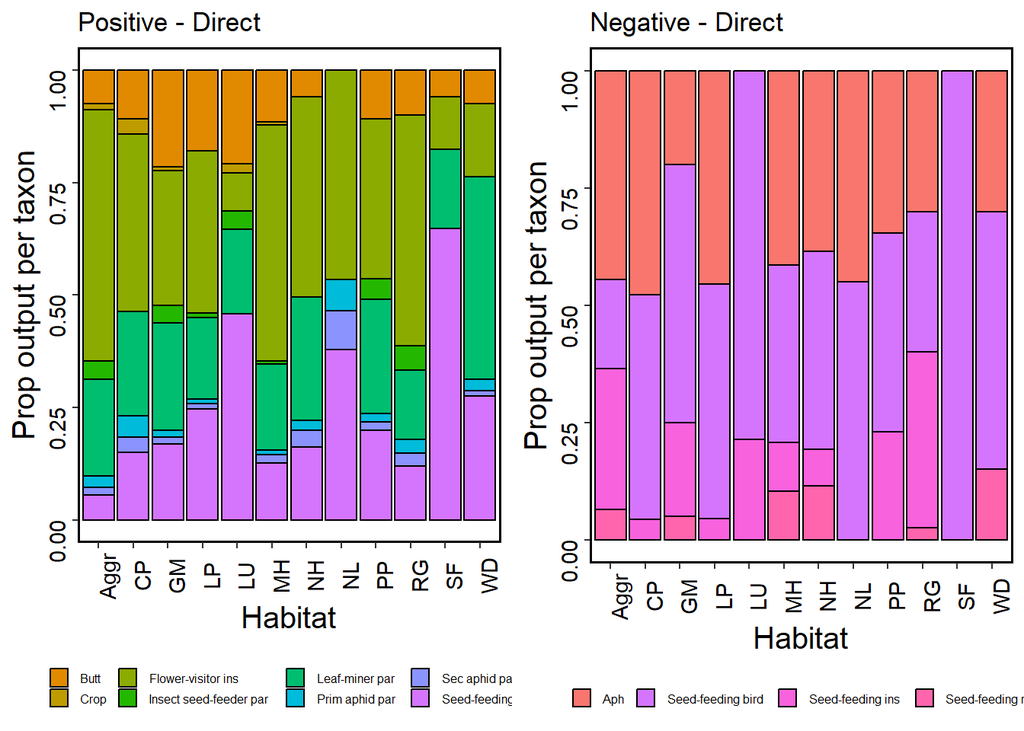

### 5.2.2 Indirect effect on ES

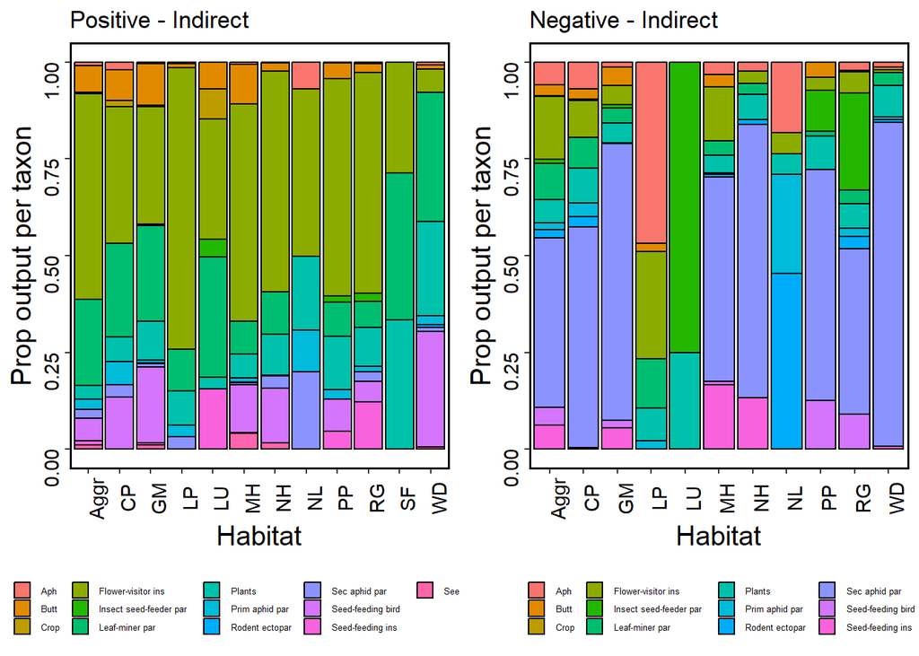

# 6 Next steps…

## 6.1 Data

- Seed-feeding birds (birds that predate seeds) have three associated ES: bird watching, crop damage, and seed dispersal. However, not all species disperse seeds. Should we check the bird list and keep “seed dispersal” just for those recorded dispersing seeds? Most of them also eat insects (“pest control”). Waiting for Darren

## 6.2 Estimation of direct ES

**Potential index**

$$I_i^\alpha = N_i^\alpha \times
S_i^\alpha$$

Where $I_i^\alpha$ represent the weight of the direct ecosystem provision for species $i$ in the layer $\alpha$, $N_i^\alpha$ represent the abundance of species $i$, and $S_i^\alpha$ represent the size of species $i$.

$S$ could be a constant value based on the taxonomic groups:

- Small (insects) = 0.1
- Medium (rodents, birds) = 0.5
- Big (crops) = 0.9

## 6.3 Multilayer

**Intralayer links between 0 and 1**

Intralayer weighted link connecting species $j$ with species $i$ is defined as $w_{ji}^\alpha=A_{j}^\alpha\times A_{i}^\alpha$

where $A_j^\alpha$ and $A_i^\alpha$ represent the relative abundance of species $j$ and $i$ in their trophic group in the layer $\alpha$.

**Interlayer links**

Interlayer weighted link connecting species $j$ with itself across habitats is defined as $w_{j}^{\alpha\beta}= ...$

The formula should include information of distances between habitats $\alpha$ and $\beta$ and the dispersal ability of the trophic group to which the species belong.

The distance component could be based on the distance between every two layers ($d^{\alpha\beta}$) and the distance between the two closest layers in the network (shortest $d$), to create a normalized scale between 0 and 1:

Distance component $= log(shortest d)/log(d^{\alpha\beta})$

We can add the dispersal ability of the species $j$ by multiplying the distance component to a constant representing the trophic group of the species. For example, it could be 1 for birds.

## 6.4 Land use change simulation

To simulate land use change, we change the management scenario gradually from extensive to intensive and test robustness.

**Habitat management change**

Let’s suppose we have these habitat management scenarios:

| Scenario | Explanation | Habitats (n) | Habitat codes |
| --- | --- | --- | --- |
| Extensive | All habitats | 11 | CP, SF, GM, LP, LU, MH, NH, NL, PP, RG, WD |
| Semi-extensive | Diverse field margin management | 9 | CP, SF, GM, LP, LU, MH, NH, NL, PP |
| Moderate | Grass field margin management | 7 | CP, SF, GM, LP, LU, NL, PP |
| Semi-intensive | Crops, pastures and fallow rotation | 6 | CP, SF, LP, LU, NL, PP |
| Intensive | Crops and pastures with no rotation | 5 | CP, LP, LU, NL, PP |

Habitats’ codes: CP, Crops; SF, Spring fallow; GM, Grass margin; LP, Ley pasture; LU, Lucerne; MH, Mature hedgerow; NH, New hedgerow; NL, New ley; PP, Permanent pasture; RG, Rough ground; WD, Woodland; ST, Standing trees.

Changing from extensive (A) to semi-intensive (B) scenario will follow the next steps:

1. Replace habitats that are in (A) but not in (B) to crop production (CP).
2. The new habitats will contain:
- same plant species as CP.
- animals that were in the previous habitat and were recorded interacting with the plants in CP.
- try to include a spillover index between habitats according to the dispersal ability of the trophic group (for example, high (1) for birds and rodents), which allow species to move to the new habitat (Darren proposed it)
3. Abundances of species will be proportional to the size of the new habitat (next step)

**Robustness**

How to include interlayer links during the extinction simulation?